# Assignment: Palmer Penguins

2023-12-03

# QUESTION 01: Data Visualisation for Science Communication

## a) Provide your figure here:

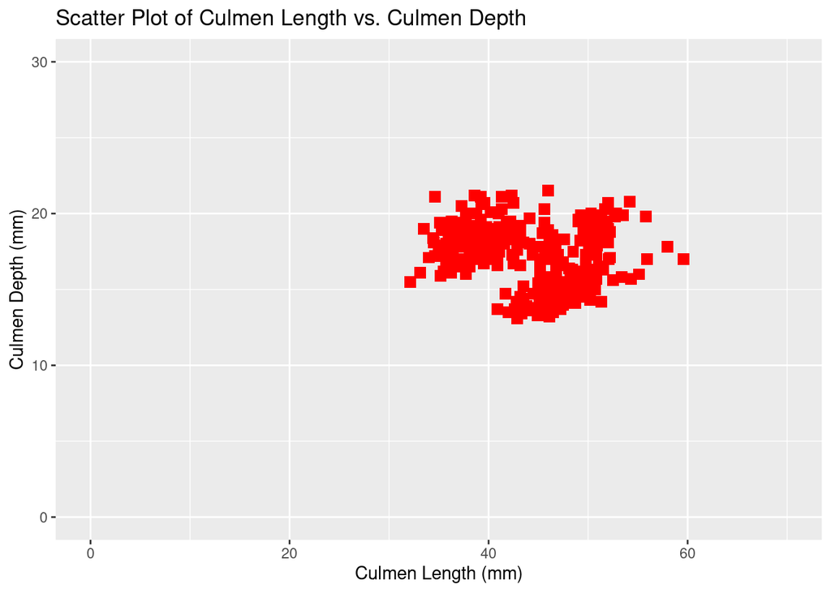

# b) How my design choices mislead the reader about the underlying data:

As can be seen I chose to perform a scatter plot of Culmen length (mm) against Culmen depth (mm). I performed this comparison across the entire species data set without any form of partitioning based on species. It appears based on this graph that there is either a non-existent correlation between Culmen length and depth, or slightly negative one and therefore heavily misleads the reader. I say this, because simply by separating the data points relative to the species they belong to, there is a very clear positive relationship between culmen length and depth that is shared across all three species. Hence this is a case of Simpson’s paradox, whereby not properly partitioning data sets can result in the masking of a signal, or even implying the opposite correlation to reality (Sprenger et al, 2021).

Additionally I have chosen a point size and shape that is too large and therefore makes it hard for the reader to distinguish discreet data points and therefore properly observe how many there are and potentially what correlations the data could be presenting. This is a typical case of overplotting.

I have also adjusted the sizes of the x and y axes. The limits I have specified don’t effectively capture the space inhabited by the data set and instead contains a lot of empty space. This misleads the reader as it distorts the patterns that may exist in the data, as seen here due to the the x axis having a larger maximum limit that the y axis the data points are stretched horizontally. This would make it appear as though less of a correlation exists between these two variables than may in fact be the case.

# References:

Sprenger, Jan and Naftali Weinberger, “Simpson’s Paradox”, The Stanford Encyclopedia of Philosophy (Summer 2021 Edition), Edward N. Zalta (ed.), URL = https://plato.stanford.edu/archives/sum2021/entries/paradox-simpson/.

Remove Your Rose Tinted Glasses: Data Visualizations Designed to Mislead URL = https://www.datapine.com/blog/misleading-data-visualization-examples/#examples

What is Overplotting? URL = https://www.displayr.com/what-is-overplotting/

# QUESTION 02: Data analysis pipeline

# Introduction:

In this analysis, the Palmer Penguins dataset - which contains a variety of physiological as well as geographical information on three penguin species; Adelie Penguin (Pygoscelis adeliae), Gentoo penguin (Pygoscelis papua) and Chinstrap penguin (Pygoscelis antarctica). In this study I endevoured to explore the possible relationship between the morphological variables culmen length and culmen depth across these three species. The dimensions of the culmen has significant implications to the ecology of the penguin as this will impact feeding behaviour and niche of these birds. Existing relationships between culmen length and depth could infer upon such feeding ecology as well as indicate functional constraint in morphospace. For this reason this study aims to identify a possible correlative relationship between culmen length and depth.

```r
# First I install and load the required packages:

install.packages(c("ggplot2", "palmerpenguins", "janitor", "dplyr", "cowplot"))
library(ggplot2)
library(palmerpenguins)
library(janitor)
library(dplyr)
library(cowplot)
```

I begin with cleaning my data set

```r
# Second I load and clean the data set using functions from my cleaning.r file.

source("functions/cleaning.r")

# The function write.csv is used to upload a csv file copy of the penguins_raw dataset to my data folder.

write.csv(penguins_raw, "data/penguins_raw.csv")

# I then use the function clean_column_names to convert the column names in the data set into a format that is conducive to being used in R.

penguins_clean <- clean_column_names(penguins_raw)

# The resultant file is saved as penguins_clean.csv into the data folder allowing the relevant changes to the data set to be observed transparently.

write.csv(penguins_clean, "data/penguins_clean.csv")

# I use the function subset_columns to subset the penguins_clean dataset for the variables I am interested in, these being species, culmen length and culmen depth.

subset_data_results <- subset_columns(penguins_clean, c("species", "culmen_length_mm", "culmen_depth_mm"))

# This produces a subsetted dataset called subset_data_results that is saved once again as a csv file to my data folder to aid in transparently showing how the data has been handled. I believe this is useful for transparency, as well as producing a copy of the dataset that could be exported to other software easily for use by other researchers.

write.csv(subset_data_results, "data/subset_data_results")

# Next I employ a function called filter_data, that unlike subset_columns, separates out the data set by the identities of specific rows and compiles them into their own filtered data set. Here I use this to separate out my subdivided data set into three smaller data sets for each of the species of penguin.

gentoo_dataset <- filter_data(
  subset_data_results,
  list(species = ("Gentoo penguin (Pygoscelis papua)")),
  "data/",
  "gentoo_data"
)

adelie_dataset <- filter_data(
  subset_data_results,
  list(species = ("Adelie Penguin (Pygoscelis adeliae)")),
  "data/",
  "adelie_data"
)

chinstrap_dataset <- filter_data(
  subset_data_results,
  list(species = ("Chinstrap penguin (Pygoscelis antarctica)")),
  "data/",
  "chinstrap_data"
)

# This provides me with three species specific data sets that contain only the variables I am interested in (culmen length and culmen depth). In addition to this, my filter_data function removes all NA data entries by nesting the remove_NA function and then uploading this filtered data set as it's own csv file, the name of which is specified when the filter function is called, to the data folder. I use this function to create all three data sets.
```

Now that I have successfully cleaned and subdivided the penguins_raw data set to three smaller data sets, one for each species, I can look at exploring the data. Here I use an exploratory scatter plot function to look for evidence of correlation that I can then statistically interrogate later.

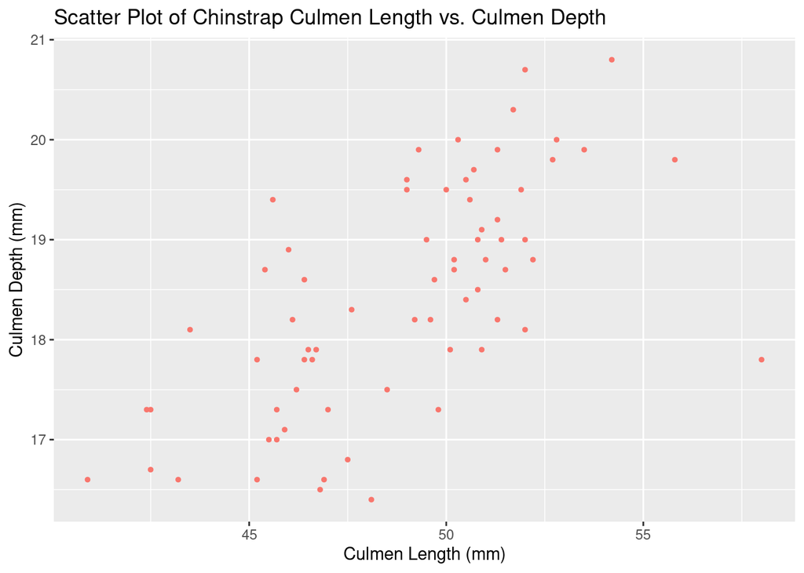

```r
# I call the functions for plotting from my illustration.r folder

source("functions/illustration.r")

# I use a function called exp_chinstrap_plot to perform the same graphical procedure on each and produce the following plots as seen below. In this function I can specify dimensions and text of the produced figures when the function is called.

exp_chinstrap_plot <- exp_create_scatter_plot(chinstrap_dataset, "culmen_length_mm", "culmen_depth_mm", "species",
                    "Scatter Plot of Chinstrap Culmen Length vs. Culmen Depth",
                    "Culmen Length (mm)", "Culmen Depth (mm)", "species",
                    label_width = 30, strip_text_size = 10.5, strip_text_hjust = 0.5, strip_text_margin = 4,
                    point_size = 1, facet_ncol = 5)
```

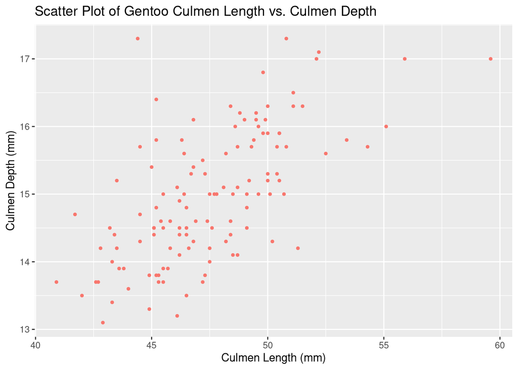

```r
exp_gentoo_plot <- exp_create_scatter_plot(gentoo_dataset, "culmen_length_mm", "culmen_depth_mm", "species",
                    "Scatter Plot of Gentoo Culmen Length vs. Culmen Depth",
                    "Culmen Length (mm)", "Culmen Depth (mm)", "species",
                    label_width = 30, strip_text_size = 10.5, strip_text_hjust = 0.5, strip_text_margin = 4,
                    point_size = 1, facet_ncol = 5)
```

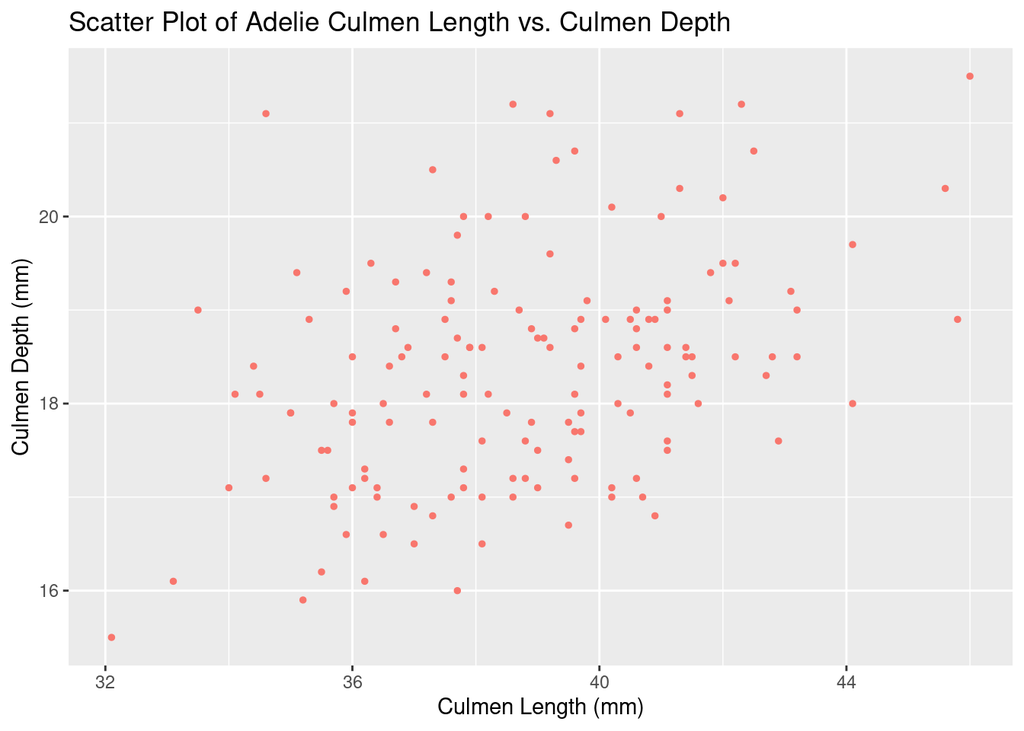

```r
exp_adelie_plot <- exp_create_scatter_plot(adelie_dataset, "culmen_length_mm", "culmen_depth_mm", "species",
                    "Scatter Plot of Adelie Culmen Length vs. Culmen Depth",
                    "Culmen Length (mm)", "Culmen Depth (mm)", "species",
                    label_width = 30, strip_text_size = 10.5, strip_text_hjust = 0.5, strip_text_margin = 4,
                    point_size = 1, facet_ncol = 5)
```

After creating a plot of culmen length versus culmen depth for each species, I use my figure saving function save_ggplot to save each of these exploratory figures to my figures folder. I specify saving these in a pdf format as this prevents the graphs from distorting when being uploaded or viewed elsewhere and at different magnifications improving their transparency and accessibility. The type of saved file can be changed, for example to png, by changing the filename of the figure when the function is called. This provides a level of flexibility to the figures in case they needed to be used for different purposes such as in a presentation or paper.

```r
# The function allows for the file type to be specified within the name, as well as the location to be saved, which I have input as my figures folder

save_ggplot(exp_gentoo_plot, "exp_gentoo_plot.pdf", "figures/", width = 6, height = 6, dpi = 300)
save_ggplot(exp_chinstrap_plot, "exp_chinstrap_plot.pdf", "figures/", width = 6, height = 6, dpi = 300)
save_ggplot(exp_adelie_plot, "exp_adelie_plot.pdf", "figures/", width = 6, height = 6, dpi = 300)
```

# Hypothesis:

Looking at my exploratory plots it is apparent that a positive correlation exists between culmen length and culmen depth within each penguins species. Hence my null hypothesis is that there is no statistically significant correlation between culmen length and culmen depth within the penguin species Gentoo, Adelie amd Chinstrap. My alternate hypothesis is that there is a statistically significant correlation between culmen length and culmen depth within the penguin species Gentoo, Adelie and Chinstrap.

# Statistical Methods:

Similarly, I performed a linear regression test on each species using the function linear_regression_by_species that outputs the summary of this regression analysis after use.

```r
# I call my statistical functions from my statistics folder

source("functions/statistics.r")

# statistics for Gentoo penguins

# The first statistical test performs a person's rank correlation test on the species data to provide a general idea as to the strength of the correlation

gentoo_correlation_result <- correlation_test_by_species(gentoo_dataset, "species", "Gentoo penguin (Pygoscelis papua)", "culmen_length_mm", "culmen_depth_mm")
```

```
##
##  Pearson's product-moment correlation
##
## data:  subset_data[[var1]] and subset_data[[var2]]
## t = 9.2447, df = 121, p-value = 1.016e-15
## alternative hypothesis: true correlation is not equal to 0
## 95 percent confidence interval:
##  0.5262952 0.7365271
## sample estimates:
##       cor
## 0.6433839
```

```r
# The second test is carried out by a linear regression function that determines the predictive capacity of culmen length on determining culmen depth and in doing so identifies the statistical significance of this correlation

gentoo_regression_result <- linear_regression_by_species(gentoo_dataset, "species", "Gentoo penguin (Pygoscelis papua)", "culmen_length_mm", "culmen_depth_mm")
```

```
##
## Call:
## lm(formula = subset_data[[var1]] ~ subset_data[[var2]])
##
## Residuals:
##     Min      1Q  Median      3Q     Max
## -7.7888 -1.4097  0.1361  1.3882  8.0174
##
## Coefficients:
##                     Estimate Std. Error t value Pr(>|t|)
## (Intercept)          17.2295     3.2818   5.250 6.60e-07 ***
## subset_data[[var2]]   2.0208     0.2186   9.245 1.02e-15 ***
## ---
## Signif. codes:  0 '***' 0.001 '**' 0.01 '*' 0.05 '.' 0.1 ' ' 1
##
## Residual standard error: 2.369 on 121 degrees of freedom
## Multiple R-squared:  0.4139, Adjusted R-squared:  0.4091
## F-statistic: 85.46 on 1 and 121 DF,  p-value: 1.016e-15
```

```r
# These statistical analyses are easily repeated identically for the other species data sets thanks to them being contained within functions I can call multiple times.

# statistics for Adelie penguins

adelie_correlation_result <- correlation_test_by_species(adelie_dataset, "species", "Adelie Penguin (Pygoscelis adeliae)", "culmen_length_mm", "culmen_depth_mm")
```

```
##
##  Pearson's product-moment correlation
##
## data:  subset_data[[var1]] and subset_data[[var2]]
## t = 5.1933, df = 149, p-value = 6.674e-07
## alternative hypothesis: true correlation is not equal to 0
## 95 percent confidence interval:
##  0.2472226 0.5187796
## sample estimates:
##       cor
## 0.3914917
```

```r
adelie_regression_result <- linear_regression_by_species(adelie_dataset, "species", "Adelie Penguin (Pygoscelis adeliae)", "culmen_length_mm", "culmen_depth_mm")
```

```
##
## Call:
## lm(formula = subset_data[[var1]] ~ subset_data[[var2]])
##
## Residuals:
##     Min      1Q  Median      3Q     Max
## -6.5513 -1.8016  0.0055  1.6771  6.5341
##
## Coefficients:
##                     Estimate Std. Error t value Pr(>|t|)
## (Intercept)           23.068      3.034   7.603 3.01e-12 ***
## subset_data[[var2]]    0.857      0.165   5.193 6.67e-07 ***
## ---
## Signif. codes:  0 '***' 0.001 '**' 0.01 '*' 0.05 '.' 0.1 ' ' 1
##
## Residual standard error: 2.459 on 149 degrees of freedom
## Multiple R-squared:  0.1533, Adjusted R-squared:  0.1476
## F-statistic: 26.97 on 1 and 149 DF,  p-value: 6.674e-07
```

```r
# statistics for Chinstrap penguins

chinstrap_correlation_result <- correlation_test_by_species(chinstrap_dataset, "species", "Chinstrap penguin (Pygoscelis antarctica)", "culmen_length_mm", "culmen_depth_mm")
```

```
##
##  Pearson's product-moment correlation
##
## data:  subset_data[[var1]] and subset_data[[var2]]
## t = 7.0146, df = 66, p-value = 1.526e-09
## alternative hypothesis: true correlation is not equal to 0
## 95 percent confidence interval:
##  0.4917326 0.7717134
## sample estimates:
##       cor
## 0.6535362
```

```r
chinstrap_regression_result <- linear_regression_by_species(chinstrap_dataset, "species", "Chinstrap penguin (Pygoscelis antarctica)", "culmen_length_mm", "culmen_depth_mm")
```

```
##
## Call:
## lm(formula = subset_data[[var1]] ~ subset_data[[var2]])
##
## Residuals:
##     Min      1Q  Median      3Q     Max
## -5.1163 -1.2641 -0.1254  1.4807 10.3590
##
## Coefficients:
##                     Estimate Std. Error t value Pr(>|t|)
## (Intercept)           13.428      5.057   2.655  0.00992 **
## subset_data[[var2]]    1.922      0.274   7.015 1.53e-09 ***
## ---
## Signif. codes:  0 '***' 0.001 '**' 0.01 '*' 0.05 '.' 0.1 ' ' 1
##
## Residual standard error: 2.547 on 66 degrees of freedom
## Multiple R-squared:  0.4271, Adjusted R-squared:  0.4184
## F-statistic: 49.21 on 1 and 66 DF,  p-value: 1.526e-09
```

# Create and save results figures:

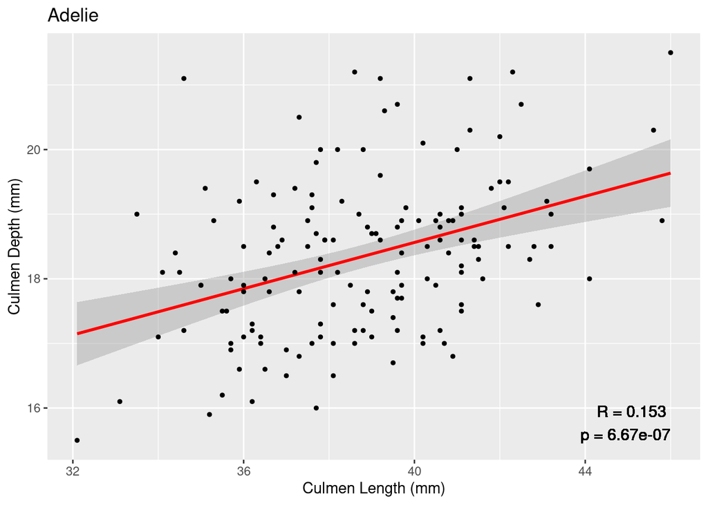

```r
source("functions/illustration.r")

# I use the function lm_create_scatter_plot() to produce a graph for each individual species. Having this as a function made producing these graphs faster as well as ensured they were being produced the same way.

adelie_plot <- lm_create_scatter_plot(adelie_dataset, "culmen_length_mm", "culmen_depth_mm",
                    "Adelie",
                    "Culmen Length (mm)", "Culmen Depth (mm)",
                    point_size = 1)
```

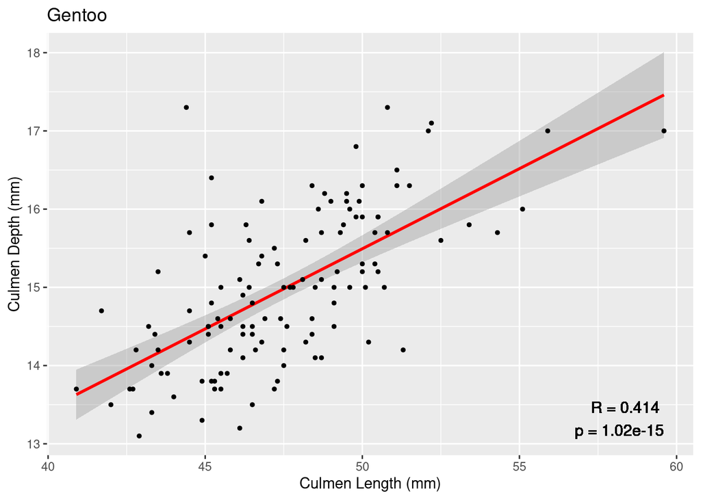

```r
gentoo_plot <- lm_create_scatter_plot(gentoo_dataset, "culmen_length_mm", "culmen_depth_mm",
                    "Gentoo",
                    "Culmen Length (mm)", "Culmen Depth (mm)",
                    point_size = 1)
```

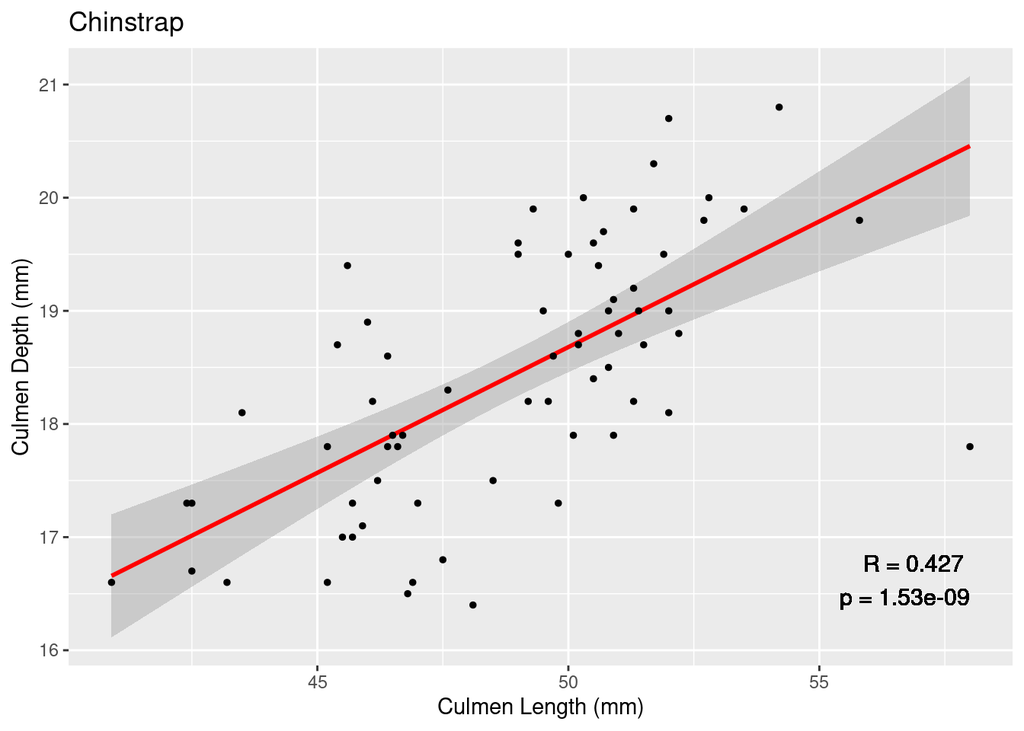

```r
chinstrap_plot <- lm_create_scatter_plot(chinstrap_dataset, "culmen_length_mm", "culmen_depth_mm",
                    "Chinstrap",
                    "Culmen Length (mm)", "Culmen Depth (mm)",
                    point_size = 1)
```

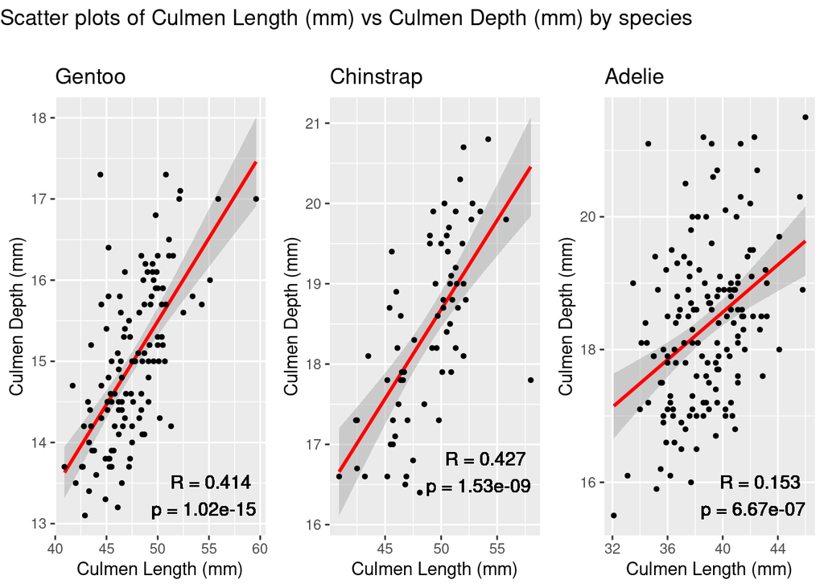

```r
# The resulting figures show the scatter plot spread of data, as well as having the regression line with a 95% confidence interval added over the top of it.

# Additionally, the function plots these graphs with vital information from the regression analysis such as the p-value (p) and the R squared value (R).

# My original question as to whether there was a statistically significant correlation between culmen length and culmen depth was addressed to each of these individual species. For this reason, I thought it would be appropriate to construct a facetting function that could take inputs of other graphs and combine these together to be viewed in one figure. I did this with each of the previously created individual species plots to produce a combined plot that shows the differences in data spread and statistical results.

combined_species_plot <- combine_and_facet_plots(list(gentoo_plot, chinstrap_plot, adelie_plot), facet_labels = NULL, "Scatter plots of Culmen Length (mm) vs Culmen Depth (mm) by species")
```

```r
# After the creation of each figure, I once again use my save_ggplot() function to save the figures to my figures folder.

save_ggplot(adelie_plot, "adelie_plot.pdf", "figures/", width = 6, height = 6, dpi = 300)
save_ggplot(gentoo_plot, "gentoo_plot.pdf", "figures/", width = 6, height = 6, dpi = 300)
save_ggplot(chinstrap_plot, "chinstrap_plot.pdf", "figures/", width = 6, height = 6, dpi = 300)
save_ggplot(combined_species_plot, "combined_species_plot.pdf", "figures/", width = 6, height = 6, dpi = 300)
```

# Results & Discussion:

Starting with the results of the Pearson’s product-moment correlation analyses, it is clear that there is a widely conserved positive correlation between culmen length and culmen depth across all three penguin species. Gentoo (~0.64), Adelie (~0.39) and Chinstrap (~0.65). It is clear however that the strongest correlations were seen in both Gentoo and Chinstrap penguins whereas the Adelie’s is noticeably lower.

# Conclusion:

Future work could look to test this relationship across a wider variety of penguin species as well as potentially identify and test the influence of covariates on these variables that better explain the varitation seen here. In addition, the potential ecological implications of this correlation could be interrogated with respect to feeding for example, as this has often dictated bill morphology in other types of island birds such as the Galapogas Finches (De León et al, 2014).

# Paper references:

Petalas, Christina et al. “Foraging Niche Partitioning in Sympatric Seabird Populations.” Scientific reports 11.1 (2021): 2493–12. Web.

De León, L. F. et al. “Darwin’s Finches and Their Diet Niches: The Sympatric Coexistence of Imperfect Generalists.” (2014): n. pag. Web.

# Package references:

## ggplot2:

H. Wickham. ggplot2: Elegant Graphics for Data Analysis. Springer-Verlag New York, 2016.

## palmerpenguins:

Horst AM, Hill AP, Gorman KB (2020). palmerpenguins: Palmer Archipelago (Antarctica) penguin data. R package version 0.1.0. https://allisonhorst.github.io/palmerpenguins/. doi: 10.5281/zenodo.3960218.

## janitor:

Firke S (2023). *janitor: Simple Tools for Examining and Cleaning Dirty Data*. R package version 2.2.0, https://CRAN.R-project.org/package=janitor.

## dplyr:

Wickham H, François R, Henry L, Müller K, Vaughan D (2023). *dplyr: A Grammar of Data Manipulation*. R package version 1.1.3, https://CRAN.R-project.org/package=dplyr.

## cowplot:

Wilke C (2020). *cowplot: Streamlined Plot Theme and Plot Annotations for ‘ggplot2’*. R package version 1.1.1, https://CRAN.R-project.org/package=cowplot.

## QUESTION 3: Open Science

### a) GitHub

*Upload your RProject you created for **Question 2** and any files and subfolders used to GitHub. Do not include any identifiers such as your name. Make sure your GitHub repo is public.*

*GitHub link:*

https://github.com/user39201/assignment_palmer_penguins

*You will be marked on your repo organisation and readability.*

### b) Share your repo with a partner, download, and try to run their data pipeline.

*Partner’s GitHub link:*

https://github.com/userSGK4/Reproduce-Assignment.git

*You **must** provide this so I can verify there is no plagiarism between you and your partner.*

### c) Reflect on your experience running their code. (300-500 words)

### What elements of your partner’s code helped you to understand their data pipeline?

The effective use of functions, held within their own folder made it easy to find and understand the code that was being run. Furthermore, the names of the functions were descriptive and provided a good indication of the procedure they were responsible for. Providing separate folders for saving data and figures to made seeing the progression of the analysis clear. In addition to this they had all of the packages they used cited in their references.

### Did it run? Did you need to fix anything?

Upon my first run through of the code, the majority of it functioned perfectly. I experienced one issue with the function plot_bar_BodyMass_Sex which in the functions folder was named as such, but in the source code called plot_bar_BodyMass_Sex2. This was a minor error that could be easily remedied by ensuring the function was called plot_bar_BodyMass_Sex in both instances.

### What suggestions would you make for improving their code to make it more understandable or reproducible, and why?

In terms of making the code more understandable, it would be useful to ensure all the data and ideally objects/functions were in lower case to ensure errors don’t acrew due to case sensitivity such as Gentoo_only.csv and figures like Figure_2_Bar_Presentation.png. Secondly, I think it could be useful to write a csv file of the Penguins_cleaned data frame to the data folder so that the changes to the data set can be followed throughout the study. I believe it could also be useful to save the figures in a vector or pdf format, as these are better for display across multiple platforms and reproducibility.

###If you needed to alter your partner’s figure using their code, do you think that would be easy or difficult, and why?

They made very good use of the functions folder that allowed me to easily access and identify the error I encountered. Furthermore, the effective use of functions means that I believe alteration to the figure would be much easier as the plotting functions are easy to follow and modify, without having to edit the same code multiple times which could introduce flaws.

### d) Reflect on your own code based on your experience with your partner’s code and their review of yours. (300-500 words)

### What improvements did they suggest, and do you agree?

The first suggestion made was that I should include my code annotation within my code chunks using the # rather than between them like I have. I agree that this introduces some complication, but is based on a misunderstanding from the template on my part where it instructed *Between your code, communicate clearly what you are doing and why.* I acknowledge my mistake and agree that within code annotation would be an improvement.

In addition to this they suggested that upon cleaning my data I should use the function head() to show the changes made. I agree that this could be useful, but I did make the effort to write my data to csv files at every point of modification to show the changes that had been made, but do agree that the head() function could speed this process up.

Finally they suggest I could improve my saving function by specifying in the main code that the width, height, resolution, and scaling were variables rather than being specified in the function. I agree that this could help with reproducibility as it could make altering the dimensions of the saved file more specific to the requirements of the researcher aiming to generate the figures.

### What did you learn about writing code for other people?

I learned lots about the way that I write code myself. Being able to evaluate someone else’s code actually identified many problems I have in my own code. For this reason, the primary takeaway on my part was that despite my programming style being understandable to myself, it likely isn’t as conducive for others and annotating my code clearly, as well as organising relevant files appropriately is extremely important as it minimises the possibility of others becoming confused. Additionally, it provided me with an alternative perspective as I could see what aspects were prioritised by other programmers and how this compared to my own priorities. Often I found where my priorities failed to overlap represented the gaps and or areas I didn’t consider deeply enough and in doing so highlighted where I could make progress. For example in making my functions more flexible so that variables could be specified when the function was called, rather than already specified in the function itself.

In terms of reproducibility and replicability, writing code for others showed me that transparency and clarity in explanation and instruction within projects is vital to ensure useage by other researchers. The way data is handled, organised and exported must all be in a manner that any can understand to a level where they can properly conceptualise and more importantly interrogate the conclusions you draw from them.